# Formative Assessment 11: Mixed-Design Repeated Measures ANOVA

BIO2105 (Section 4 - Group 2) - Biostatistics

2026-11-22

**Authors:** Ayap, Princess Amberlin Mae | Domingo, Margaret | Ferrer, Phoebe Anne | Gamido, Dhen Angelo | Pepito, Yvonna Roselle

# Introduction and Research Objectives

## Research Background

In an experimental study of rat growth (Box, 1950), rats were assigned to three treatment groups: **Control** (no additive), **Thiouracil**, and **Thyroxin** administered via drinking water. Body weights were recorded across five measurement occasions: **Baseline (Week 0)** through **Week 4**.

Following an accident, three rats were removed from the Thyroxin group, leaving $N = 27$ rats and 135 total observations.

## Research Objective

To determine whether rat body weight differs significantly across treatment groups and measurement occasions, and specifically to evaluate whether growth trajectories over time depend on the treatment received (**Treatment** $\times$ Time Interaction).

# 1. Data Preparation and Exploration

```r
# Load required libraries
library(nlmm)
library(tidyverse)
library(rstatix)
library(ggpubr)

# Load dataset
data("rats", package = "nlmm")

# Format factor variables with clear labels
rats <- rats %>%
  mutate(
    id = factor(id),
    trt = factor(
      trt,
      levels = c(1, 2, 3),
      labels = c("Control", "Thiouracil", "Thyroxin")
    ),
    time = factor(
      time,
      levels = 0:4,
      labels = c("Week 0", "Week 1", "Week 2", "Week 3", "Week 4")
    )
  )

# Inspect data structure
str(rats)
```

```
## 'data.frame':    135 obs. of  4 variables:
##  $ id  : Factor w/ 27 levels "1","2","3","4",..: 1 2 3 4 5 6 7 8 9 10 ...
##  $ time: Factor w/ 5 levels "Week 0","Week 1",..: 1 1 1 1 1 1 1 1 1 1 ...
##  $ trt : Factor w/ 3 levels "Control","Thiouracil",..: 1 1 1 1 1 1 1 1 1 1 ...
##  $ y   : int  57 60 52 49 56 46 51 63 49 57 ...
```

```r
dim(rats)
```

```
## [1] 135   4
```

```r
knitr::kable(rats)
```

| id | time | trt | y |
| --- | --- | --- | --- |
| 1 | Week 0 | Control | 57 |
| 2 | Week 0 | Control | 60 |
| 3 | Week 0 | Control | 52 |
| 4 | Week 0 | Control | 49 |
| 5 | Week 0 | Control | 56 |
| 6 | Week 0 | Control | 46 |
| 7 | Week 0 | Control | 51 |
| 8 | Week 0 | Control | 63 |
| 9 | Week 0 | Control | 49 |
| 10 | Week 0 | Control | 57 |
| 11 | Week 0 | Thiouracil | 61 |
| 12 | Week 0 | Thiouracil | 59 |
| 13 | Week 0 | Thiouracil | 53 |
| 14 | Week 0 | Thiouracil | 59 |
| 15 | Week 0 | Thiouracil | 51 |
| 16 | Week 0 | Thiouracil | 51 |
| 17 | Week 0 | Thiouracil | 56 |
| 18 | Week 0 | Thiouracil | 58 |
| 19 | Week 0 | Thiouracil | 46 |
| 20 | Week 0 | Thiouracil | 53 |
| 21 | Week 0 | Thyroxin | 59 |
| 22 | Week 0 | Thyroxin | 54 |
| 23 | Week 0 | Thyroxin | 56 |
| 24 | Week 0 | Thyroxin | 59 |
| 25 | Week 0 | Thyroxin | 57 |
| 26 | Week 0 | Thyroxin | 52 |
| 27 | Week 0 | Thyroxin | 52 |
| 1 | Week 1 | Control | 86 |
| 2 | Week 1 | Control | 93 |
| 3 | Week 1 | Control | 77 |

[output cut: 105 more lines]

```r
table(rats$trt)
```

```
##
##    Control Thiouracil   Thyroxin
##         50         50         35
```

### Guide Question Answer

- **Why is the dataset in long format?**  
  *[The data-set is in long format because there are repeating values found in column one, the subject identifier. ID is necessary is order to compare the changes in a participant as time passes, since the data-set aims to compare weekly changes in weight gain depending on treatment type.]*

# 2. Descriptive Statistics and Data Visualization

### 2.1 Descriptive Summary

```r
rats %>%
  group_by(trt, time) %>%
  get_summary_stats(y, type = "mean_sd")
```

```
## # A tibble: 15 × 6
##    time   trt        variable     n  mean    sd
##    <fct>  <fct>      <fct>    <dbl> <dbl> <dbl>
##  1 Week 0 Control    y           10  54    5.44
##  2 Week 1 Control    y           10  78.5  9.64
##  3 Week 2 Control    y           10 106    9.92
##  4 Week 3 Control    y           10 130.  12.6
##  5 Week 4 Control    y           10 161.  15.2
##  6 Week 0 Thiouracil y           10  54.7  4.69
##  7 Week 1 Thiouracil y           10  76.3  7.92
##  8 Week 2 Thiouracil y           10  95.8  8.50
##  9 Week 3 Thiouracil y           10 108.   9.75
## 10 Week 4 Thiouracil y           10 124   11.3
## 11 Week 0 Thyroxin   y            7  55.6  2.99
## 12 Week 1 Thyroxin   y            7  75.9  6.44
## 13 Week 2 Thyroxin   y            7 105.  11.1
## 14 Week 3 Thyroxin   y            7 133.  17.0
## 15 Week 4 Thyroxin   y            7 163.  21.5
```

### 2.2 Visualizations

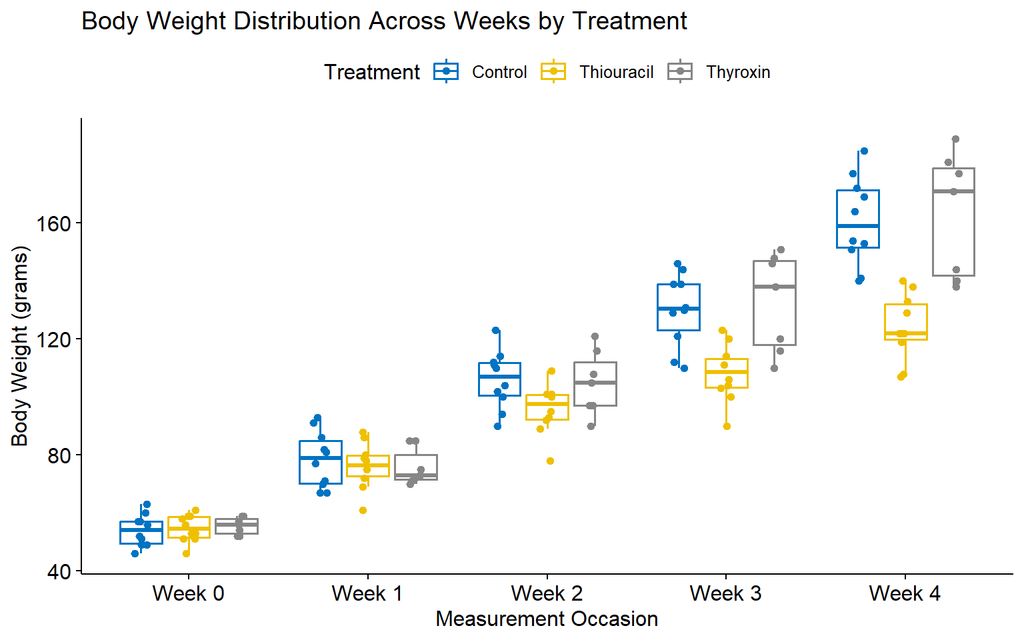

```r
# Boxplot across time points by treatment group
ggboxplot(
  rats,
  x = "time",
  y = "y",
  color = "trt",
  palette = "jco",
  add = "jitter"
) +
  labs(
    title = "Body Weight Distribution Across Weeks by Treatment",
    x = "Measurement Occasion",
    y = "Body Weight (grams)",
    color = "Treatment"
  )
```

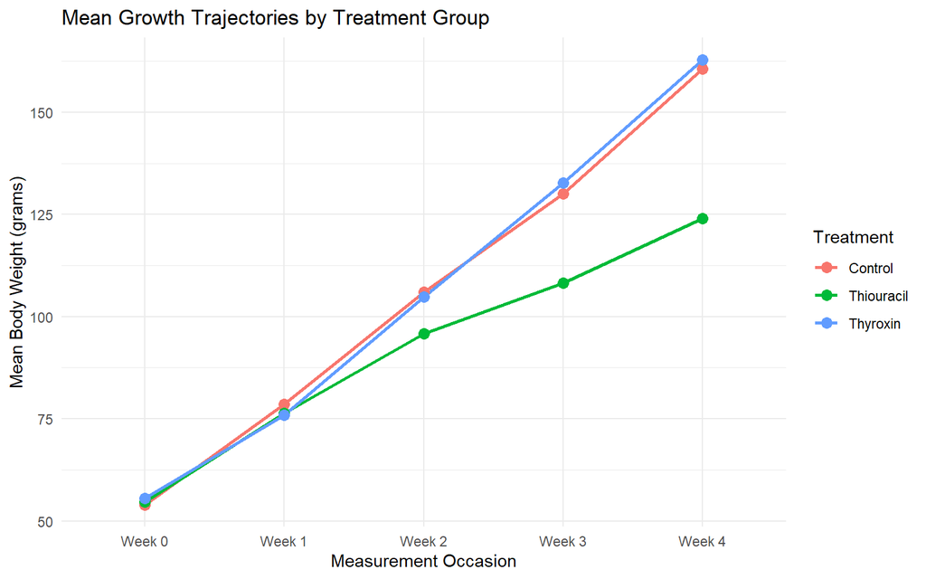

```r
# Interaction plot of mean body weights over time
rats %>%
  group_by(trt, time) %>%
  summarise(mean_weight = mean(y), .groups = "drop") %>%
  ggplot(aes(x = time, y = mean_weight, color = trt, group = trt)) +
  geom_line(linewidth = 1) +
  geom_point(size = 3) +
  labs(
    title = "Mean Growth Trajectories by Treatment Group",
    x = "Measurement Occasion",
    y = "Mean Body Weight (grams)",
    color = "Treatment"
  ) +
  theme_minimal()
```

# 3. Assumption Checking

### 3.1 Normality: Shapiro-Wilk test per cell (trt x time) and Q-Q plots

```r
rats %>%
  group_by(trt, time) %>%
  shapiro_test(y)
```

```
## # A tibble: 15 × 5
##    time   trt        variable statistic      p
##    <fct>  <fct>      <chr>        <dbl>  <dbl>
##  1 Week 0 Control    y            0.960 0.791
##  2 Week 1 Control    y            0.921 0.363
##  3 Week 2 Control    y            0.978 0.951
##  4 Week 3 Control    y            0.928 0.426
##  5 Week 4 Control    y            0.954 0.715
##  6 Week 0 Thiouracil y            0.946 0.617
##  7 Week 1 Thiouracil y            0.971 0.904
##  8 Week 2 Thiouracil y            0.941 0.562
##  9 Week 3 Thiouracil y            0.978 0.955
## 10 Week 4 Thiouracil y            0.936 0.507
## 11 Week 0 Thyroxin   y            0.888 0.264
## 12 Week 1 Thyroxin   y            0.789 0.0318
## 13 Week 2 Thyroxin   y            0.960 0.815
## 14 Week 3 Thyroxin   y            0.876 0.208
## 15 Week 4 Thyroxin   y            0.860 0.152
```

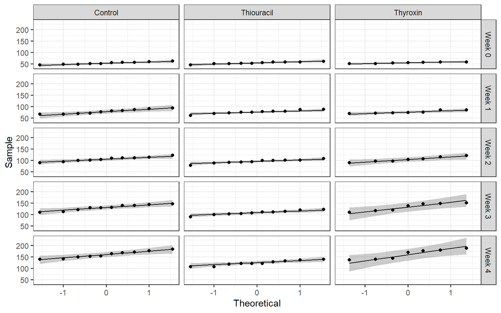

```r
ggqqplot(rats, "y", ggtheme = theme_bw()) +
  facet_grid(time ~ trt)
```

### 3.2 Outliers Check

```r
rats %>%
  group_by(trt, time) %>%
  identify_outliers(y)
```

```
## # A tibble: 2 × 6
##   time   trt        id        y is.outlier is.extreme
##   <fct>  <fct>      <fct> <int> <lgl>      <lgl>
## 1 Week 1 Thiouracil 19       61 TRUE       FALSE
## 2 Week 2 Thiouracil 19       78 TRUE       FALSE
```

### 3.3 Homogeneity of Variances: Levene’s test at each measurement occasion

```r
rats %>%
  group_by(time) %>%
  levene_test(y ~ trt)
```

```
## # A tibble: 5 × 5
##   time     df1   df2 statistic     p
##   <fct>  <int> <int>     <dbl> <dbl>
## 1 Week 0     2    24     2.06  0.149
## 2 Week 1     2    24     1.18  0.326
## 3 Week 2     2    24     0.405 0.672
## 4 Week 3     2    24     1.67  0.210
## 5 Week 4     2    24     2.28  0.124
```

### 3.4 Homogeneity of Covariance Matrices: Box’s M test on wide-format data using α = 0.001

```r
rats_wide <- rats %>%
  pivot_wider(id_cols = c(id, trt), names_from = time, values_from = y)

box_m(rats_wide[, -c(1, 2)], rats_wide$trt)
```

```
## # A tibble: 1 × 4
##   statistic p.value parameter method
##       <dbl>   <dbl>     <dbl> <chr>
## 1      22.4   0.839        30 Box's M-test for Homogeneity of Covariance Matric…
```

### 3.5 Sphericity Test and Greenhouse-Geisser Correction

```r
rats_stat_2WMAnova <- rstatix::anova_test(data = rats, dv = y, wid = id, between = trt, within = time)

rats_stat_2WMAnova$`Mauchly's Test for Sphericity`
```

```
##     Effect     W        p p<.05
## 1     time 0.011 1.41e-17     *
## 2 trt:time 0.011 1.41e-17     *
```

```r
# If p > 0.05, sphericity is met (no correction needed)
# Since Mauchly's test yielded a p = 1.41e-17 (p < 0.001) < 0.05, sphericity was violated therefore below is Greenhouse-Geisser correction being applied.
rats_stat_2WMAnova$`Sphericity Corrections`
```

```
##     Effect   GGe      DF[GG]    p[GG] p[GG]<.05   HFe      DF[HF]    p[HF]
## 1     time 0.342 1.37, 32.82 6.00e-26         * 0.356 1.42, 34.13 6.80e-27
## 2 trt:time 0.342 2.73, 32.82 1.73e-06         * 0.356 2.84, 34.13 1.13e-06
##   p[HF]<.05
## 1         *
## 2         *
```

### 4.5 Summary of Assumptions

The majority of the dataset met the assumptions for a mixed-design ANOVA, although on sphericity the Greenhouse-Geisser correction was applied. Normality was met across 14 out of 15 treatment-by-time cells ($p > 0.05$), there was a single data that stood out a bit (in Treatment 3 at Week 1 ($W = 0.789, p = 0.0318$)), although since the Q-Q plots still aligned well overall and mixed ANOVA handles slight normality deviations, this assumption holds. Rat `id = 19` (Treatment 2) had two outliers at Week 1 ($y = 61$) and Week 2 ($y = 78$), although neither was tagged as extreme (`is.extreme = FALSE`), so technically no extreme outliers came from this dataset. Both homogeneity of variances (Levene’s test, $p = 0.124\text{–}0.672$) and homogeneity of covariance matrices (Box’s M test, $\chi^2(30) = 22.4, p = 0.839$ at $\alpha = 0.001$) were satisfied. Finally, Mauchly’s test was significant ($W = 0.011, p = 1.41 \times 10^{-17} < 0.05$), which meant sphericity was violated and the Greenhouse-Geisser correction ($\varepsilon = 0.342$) was applied to the within-subjects ANOVA results.

# 4. Mixed-Design Repeated Measures ANOVA

```r
# Fit two-way mixed-design repeated measures ANOVA
rats_stat_2WMAnova <- rstatix::anova_test(
  data = rats,
  dv = y,
  wid = id,
  between = trt,
  within = time
)

# Display complete ANOVA output
rats_stat_2WMAnova
```

```
## ANOVA Table (type III tests)
##
## $ANOVA
##     Effect DFn DFd       F        p p<.05   ges
## 1      trt   2  24   7.884 2.00e-03     * 0.307
## 2     time   4  96 745.920 2.38e-71     * 0.910
## 3 trt:time   8  96  16.586 3.42e-15     * 0.310
##
## $`Mauchly's Test for Sphericity`
##     Effect     W        p p<.05
## 1     time 0.011 1.41e-17     *
## 2 trt:time 0.011 1.41e-17     *
##
## $`Sphericity Corrections`
##     Effect   GGe      DF[GG]    p[GG] p[GG]<.05   HFe      DF[HF]    p[HF]
## 1     time 0.342 1.37, 32.82 6.00e-26         * 0.356 1.42, 34.13 6.80e-27
## 2 trt:time 0.342 2.73, 32.82 1.73e-06         * 0.356 2.84, 34.13 1.13e-06
##   p[HF]<.05
## 1         *
## 2         *
```

```r
# Display Greenhouse_Geisser corrected ANOVA table
rstatix::get_anova_table(rats_stat_2WMAnova)
```

```
## ANOVA Table (type III tests)
##
##     Effect  DFn   DFd       F        p p<.05   ges
## 1      trt 2.00 24.00   7.884 2.00e-03     * 0.307
## 2     time 1.37 32.82 745.920 6.00e-26     * 0.910
## 3 trt:time 2.73 32.82  16.586 1.73e-06     * 0.310
```

# 5. Post Hoc Analysis and Interaction Decomposition

### 5.1 Treatment Differences per Week

Simple one-way ANOVAs and Tukey’s HSD pairwise comparisons were performed to determine whether significant differences existed among treatment groups at each observation week.

```r
weeks <- levels(rats$time)

for (wk in weeks) {

  cat("\n====================================\n")
  cat("RESULTS FOR", wk, "\n")
  cat("====================================\n")

  week_data <- subset(rats, time == wk)

  model <- aov(y ~ trt, data = week_data)

  cat("\nOne-way ANOVA:\n")
  print(summary(model))

  cat("\nTukey's HSD Pairwise Comparisons:\n")
  print(TukeyHSD(model))
}
```

```
##
## ====================================
## RESULTS FOR Week 0
## ====================================
##
## One-way ANOVA:
##             Df Sum Sq Mean Sq F value Pr(>F)
## trt          2   10.2   5.093   0.236  0.792
## Residuals   24  517.8  21.576
##
## Tukey's HSD Pairwise Comparisons:
##   Tukey multiple comparisons of means
##     95% family-wise confidence level
##
## Fit: aov(formula = y ~ trt, data = week_data)
##
## $trt
##                          diff       lwr      upr     p adj
## Thiouracil-Control  0.7000000 -4.487581 5.887581 0.9394817
## Thyroxin-Control    1.5714286 -4.145007 7.287864 0.7735318
## Thyroxin-Thiouracil 0.8714286 -4.845007 6.587864 0.9234749
##
##
## ====================================
## RESULTS FOR Week 1
## ====================================
##
## One-way ANOVA:
##             Df Sum Sq Mean Sq F value Pr(>F)
## trt          2   36.5   18.27   0.266  0.769
## Residuals   24 1649.5   68.73
##
## Tukey's HSD Pairwise Comparisons:
##   Tukey multiple comparisons of means
##     95% family-wise confidence level
##
## Fit: aov(formula = y ~ trt, data = week_data)
##
## $trt
##                           diff       lwr      upr     p adj
```

[output cut: 60 more lines]

```
## Residuals   24   5993     250
## ---
## Signif. codes:  0 '***' 0.001 '**' 0.01 '*' 0.05 '.' 0.1 ' ' 1
##
## Tukey's HSD Pairwise Comparisons:
##   Tukey multiple comparisons of means
##     95% family-wise confidence level
##
## Fit: aov(formula = y ~ trt, data = week_data)
##
## $trt
##                           diff       lwr       upr     p adj
## Thiouracil-Control  -36.600000 -54.24856 -18.95144 0.0000761
## Thyroxin-Control      2.257143 -17.19062  21.70491 0.9548342
## Thyroxin-Thiouracil  38.857143  19.40938  58.30491 0.0001225
```

### Interpretation

No significant treatment differences were observed during Weeks 0, 1, and 2. Although Week 2 was close to the 0.05 significance level (p = 0.0599), it was not statistically significant.

Significant treatment differences emerged during Week 3 (p = 0.000678) and Week 4 (p = 0.0000182). Tukey’s HSD results showed that Thiouracil differed significantly from both Control and Thyroxin during these later weeks. Control and Thyroxin did not significantly differ.

### 5.2 Time Differences per Treatment

Repeated-measures ANOVAs were conducted separately for each treatment group, followed by Holm-adjusted paired t-tests to determine which observation weeks differed significantly.

```r
rats <- rats[order(rats$trt, rats$id, rats$time), ]

treatments <- levels(rats$trt)

for (t in treatments) {

  cat("\n====================================\n")
  cat("RESULTS FOR", t, "\n")
  cat("====================================\n")

  treatment_data <- subset(rats, trt == t)

  cat("\nRepeated-Measures ANOVA:\n")

  model <- aov(y ~ time + Error(id/time), data = treatment_data)

  print(summary(model))

  cat("\nHolm-Adjusted Paired t-tests:\n")

  pairwise_results <- pairwise.t.test(
    x = treatment_data$y,
    g = treatment_data$time,
    paired = TRUE,
    p.adjust.method = "holm"
  )

  print(pairwise_results)
}
```

```
##
## ====================================
## RESULTS FOR Control
## ====================================
##
## Repeated-Measures ANOVA:
##
## Error: id
##           Df Sum Sq Mean Sq F value Pr(>F)
## Residuals  9   3903   433.7
##
## Error: id:time
##           Df Sum Sq Mean Sq F value Pr(>F)
## time       4  70221   17555   398.8 <2e-16 ***
## Residuals 36   1585      44
## ---
## Signif. codes:  0 '***' 0.001 '**' 0.01 '*' 0.05 '.' 0.1 ' ' 1
##
## Holm-Adjusted Paired t-tests:
##
##  Pairwise comparisons using paired t tests
##
## data:  treatment_data$y and treatment_data$time
##
##        Week 0  Week 1  Week 2  Week 3
## Week 1 1.9e-07 -       -       -
## Week 2 2.2e-08 1.2e-07 -       -
## Week 3 4.8e-08 1.9e-07 4.0e-07 -
## Week 4 2.2e-08 9.9e-08 1.2e-07 1.2e-07
##
## P value adjustment method: holm
##
## ====================================
## RESULTS FOR Thiouracil
## ====================================
##
## Repeated-Measures ANOVA:
##
## Error: id
##           Df Sum Sq Mean Sq F value Pr(>F)
```

[output cut: 38 more lines]

```
## Signif. codes:  0 '***' 0.001 '**' 0.01 '*' 0.05 '.' 0.1 ' ' 1
##
## Holm-Adjusted Paired t-tests:
##
##  Pairwise comparisons using paired t tests
##
## data:  treatment_data$y and treatment_data$time
##
##        Week 0  Week 1  Week 2  Week 3
## Week 1 9.8e-05 -       -       -
## Week 2 7.4e-05 9.8e-05 -       -
## Week 3 8.5e-05 9.8e-05 0.00014 -
## Week 4 7.4e-05 9.8e-05 9.8e-05 6.0e-05
##
## P value adjustment method: holm
```

### Interpretation

**Control:** Significant changes were observed across time, F(4,36) = 398.8, p < 0.001. All pairwise week comparisons were significant after Holm adjustment.

**Thiouracil:** Significant changes were observed across time, F(4,36) = 225.1, p < 0.001. All pairwise week comparisons were significant after Holm adjustment.

**Thyroxin:** Significant changes were observed across time, F(4,24) = 160.9, p < 0.001. All pairwise week comparisons were significant after Holm adjustment.

### 5.3 Overall Interpretation

The simple main effects analyses showed that treatment differences were not significant during Weeks 0, 1, and 2 but became significant during Weeks 3 and 4. In particular, the Thiouracil group differed significantly from the Control and Thyroxin groups during the later observation weeks.

Meanwhile, all three treatment groups showed significant changes over time. These findings suggest that the treatment trajectories diverged over the five-week period, particularly involving the Thiouracil group.

# 6. APA-Style Interpretation & Conclusion

### Conclusion

In answer to the central research question, yes—the effect of treatment on rat body weight depends significantly on the measurement occasion. While all groups begin at comparable baseline weights, growth trajectories diverge over the four-week period due to the growth-suppressing effect of Thiouracil relative to Control and Thyroxin treatments.

# References

- Box, G. E. P. (1950). Problems in the analysis of growth and wear curves. *Biometrics, 6*(4), 362–389.
- Kassambara, A. (2023). *rstatix: Pipe-Friendly Framework for Basic Statistical Tests*. R package.
- Lapointe, N. (2020). *nlmm: Generalized Linear Mixed-Effects Models*. R package dataset `rats`.